# Multilocus Genotype And Mycelial Compatability Group Assessment

# Introduction

The purpose of this document is to assess the distribution of the MLGs and MCGs within the data. Specifically, we want to know if there are any MLGs that consistently coordinate with a single MCG, or if there are anything close.

## Packages and Data

```r
library('igraph')
library('ggraph')
library('tidyverse')
library('poppr')
library('viridis')
library('visNetwork')
```

```r
load(file.path(PROJHOME, "data", "sclerotinia_16_loci.rda"))
load(file.path(PROJHOME, "data", "mlg-crosspop-graph.rda"))
dat11
```

```
This is a genclone object
-------------------------
Genotype information:

   165 original multilocus genotypes
   366 haploid individuals
    11 codominant loci

Population information:

     5 strata - MCG, Region, Source, Year, Host
    14 populations defined - NE, NY, MN, ..., France, Mexico, ND
```

```r
g11o <- igraph::cluster_optimal(graph11loc$total)
comm <- igraph::communities(g11o)
names(comm) <- c("International", "Costal", "Midwest")
comm
```

```
$International
[1] "Australia" "France"    "MN"

$Costal
[1] "CA" "NY" "OR" "WA"

$Midwest
[1] "CO" "MI" "ND" "NE"
```

```r
strata(dat11) <- strata(dat11) %>%
  mutate(MLGRegion = case_when(
    .$Region %in% comm$International ~ "International",
    .$Region %in% comm$Costal ~ "Costal",
    .$Region %in% comm$Midwest ~ "Midwest",
    TRUE ~ as.character(.$Region)
  ))
setPop(dat11) <- ~MLGRegion
pal <- unlist(map2(LETTERS[2:4], comm, function(a, b) setNames(viridis::viridis(length(b), option = a), b)))
pal <- c(pal, setNames(rep("#F6F6F6FF", 3), c("Mexico", "ID", "WI")))
strat <- bind_cols(strata(dat11),
                   other(dat11)$meta,
                   data_frame(MLG = mll(dat11, "original")))
```

# MLG table

First, it would be nice to visualize the MLGs across populations

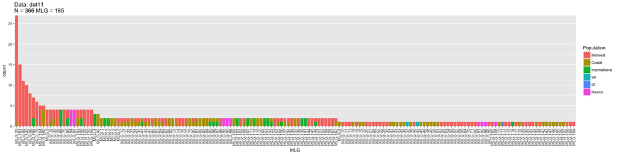

```r
mtab <- mlg.table(dat11, color = TRUE)
```

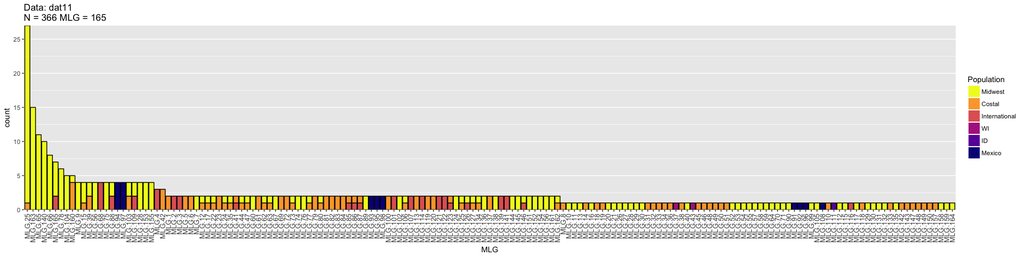

```r
mplot <- last_plot()
mplot + scale_fill_viridis(discrete = TRUE, direction = -1, option = "C") +
  aes(color = I("black"))
```

Now we can take a look at the concordance of MLGs to MCGs. We can do this by creating a contigency table. Of course, since we have 87 and well over 100 MLGs, this means that the contingency table is going to be big, so to summarize it further, I’m creating two tables, one based on MLGs that will count the number of MCGs within each MLG and vice-versa. Of course we lose information like, if an MCG contains several MLGs, how can we tell what the abundance is? A handy measure is Evenness, which scales from 0 to 1, indicating how skewed the observations are.

```r
mll.custom(dat11) <- strata(dat11)$MCG
mcgmlg <- as.data.frame(table(mll(dat11, "original"), mll(dat11, "custom"))) %>%
  setNames(c("MLG", "MCG", "Freq")) %>%
  mutate(MLG = as.character(MLG)) %>%
  mutate(MCG = as.character(MCG)) %>%
  as_tibble() %>%
  filter(Freq > 0)
mcgs <- mcgmlg %>%
  arrange(MCG) %>%
  group_by(MCG) %>%
  mutate(MLGs = sum(Freq > 0),
         Samples = sum(Freq),
         Evenness = diversity_stats(Freq)["E.5"],
         data = list(data_frame(MLG = MLG, Freq = Freq) %>% arrange(desc(Freq)))) %>%
  arrange(desc(MLGs)) %>%
  ungroup() %>%
  distinct(MCG, MLGs, Samples, Evenness, data)
mlgs <- mcgmlg %>%
  arrange(MLG) %>%
  group_by(MLG) %>%
  mutate(MCGs     = sum(Freq > 0),
         Samples  = sum(Freq),
         Evenness = diversity_stats(Freq)["E.5"],
         data     = list(data_frame(MCG = MCG, Freq = Freq) %>% arrange(desc(Freq)))) %>%
  arrange(desc(Samples), desc(MCGs)) %>%
  ungroup() %>%
  distinct(MLG, MCGs, Samples, Evenness, data)
mcgs
```

| MCG | MLGs | Samples | Evenness | data |
| --- | --- | --- | --- | --- |
| 5 | 37 | 73 | 0.4811239 |  |
| 44 | 19 | 36 | 0.6249418 |  |
| 1 | 10 | 15 | 0.8217819 |  |
| 2 | 9 | 10 | 0.9517005 |  |
| 4 | 9 | 14 | 0.7242515 |  |
| 53 | 9 | 9 | 1.0000000 |  |
| 3 | 8 | 8 | 1.0000000 |  |
| 9 | 8 | 15 | 0.5493741 |  |
| 45 | 7 | 16 | 0.6304310 |  |
| 16 | 6 | 7 | 0.9371824 |  |

[output cut: 77 more lines]

```r
mlgs
```

| MLG | MCGs | Samples | Evenness | data |
| --- | --- | --- | --- | --- |
| 25 | 5 | 27 | 0.5490333 |  |
| 163 | 2 | 15 | 0.9955736 |  |
| 65 | 2 | 11 | 0.5560301 |  |
| 140 | 3 | 10 | 0.9063854 |  |
| 66 | 1 | 8 | NaN |  |
| 165 | 3 | 7 | 0.6693363 |  |
| 78 | 4 | 6 | 0.8116548 |  |
| 160 | 4 | 5 | 0.9218931 |  |
| 104 | 2 | 5 | 0.7246677 |  |
| 109 | 3 | 4 | 0.9115303 |  |

[output cut: 155 more lines]

```r
NA
```

These tables are a good start, but we want to have a publication-ready table.

```r
fct2int <- function(x) as.integer(as.character(x))
psex_from_graph <- function(g, MLG){
  weights <- setNames(E(g)$weight, E(g)$label)
  weights <- split(weights, names(weights))
  if (length(MLG) > 1){
    weights <- weights[MLG]
    res <- 1 - vapply(weights, unique, numeric(1))
  } else {
    res <- 1 - unique(weights[[MLG]])
  }
  res
}
# Paste region and count vectors
pasteRC <- function(R, C){
  ord <- rev(order(C))
  RC <- paste(R[ord], C[ord], sep = " (")
  RC <- paste(RC, collapse = "), ")
  paste0(RC, ")")
}
mlg_table <- mcgmlg %>%
  filter(MLG %in% mlgs$MLG[1:5]) %>%
  mutate(MLG = as.integer(MLG)) %>%
  select(-Freq) %>%
  inner_join(strat) %>%
  group_by(MLG, MCG, Region) %>%
  summarize(N = n()) %>%
  ungroup() %>%
  group_by(MLG, MCG) %>%
  summarize(Region = pasteRC(Region, N), N = sum(N)) %>%
  ungroup() %>%
  mutate(mlmatch = match(MLG, mlgs$MLG[1:5])) %>%
  arrange(mlmatch, desc(N), MCG) %>%
  group_by(MLG) %>%
  mutate(Psex = psex_from_graph(graph11loc$total, as.character(unique(MLG)))) %>%
  ungroup() %>%
  select(MLG, Psex, MCG, Region) %>%
  mutate(Psex = ifelse(duplicated(MLG), "", format(Psex, scientific = FALSE, digits = 2))) %>%
  mutate(MLG = ifelse(duplicated(MLG), "", as.character(MLG)))
```

Joining, by = c(“MLG”, “MCG”) Column `MCG` joining character vector and factor, coercing into character vector

```r
mcg_table <- mcgmlg %>%
  filter(MCG %in% mcgs$MCG[1:5]) %>%
  mutate(MLG = as.integer(MLG)) %>%
  select(-Freq) %>%
  inner_join(strat) %>%
  group_by(MLG, MCG, Region) %>%
  summarize(N = n()) %>%
  ungroup() %>%
  group_by(MLG, MCG) %>%
  summarize(Region = pasteRC(Region, N), N = sum(N)) %>%
  ungroup() %>%
  mutate(mlmatch = match(MCG, mcgs$MCG[1:5])) %>%
  arrange(mlmatch, desc(N), MLG) %>%
  select(MCG, MLG, Region) %>%
  mutate(MCG = ifelse(duplicated(MCG), "", as.character(MCG))) %>%
  mutate(MLG = as.character(MLG))
```

Joining, by = c(“MLG”, “MCG”) Column `MCG` joining character vector and factor, coercing into character vector

```r
kable(mlg_table, caption = "Top 5 MLGs with associated MCGs and Regions (number of samples in parenthesis)")
```

| MLG | Psex | MCG | Region |
| --- | --- | --- | --- |
| 25 | 0.016824 | 5 | ND (15), CO (2), MI (2) |
|  |  | 13 | ND (3) |
|  |  | 60 | ND (2), WA (1) |
|  |  | 1 | NE (1) |
|  |  | 4 | MI (1) |
| 163 | 0.049932 | 45 | CO (5), ND (2), NE (1) |
|  |  | 5 | MI (7) |
| 65 | 0.000071 | 44 | NE (10) |
|  |  | 5 | MI (1) |
| 140 | 0.000155 | 8 | CO (5) |
|  |  | 5 | MI (3) |
|  |  | 20 | MI (2) |
| 66 | 0.000016 | 9 | NE (4), CO (2), MI (2) |

```r
if (!dir.exists(file.path(PROJHOME, "results/tables"))) dir.create(file.path(PROJHOME, "results/tables"))
readr::write_csv(mlg_table, path = file.path(PROJHOME, "results/tables/mlg_table.csv"))
kable(mcg_table, caption = "Top 5 MCGs with associated MLGs and Regions (number of samples in parenthesis)")
```

| MCG | MLG | Region |
| --- | --- | --- |
| 5 | 25 | ND (15), CO (2), MI (2) |
|  | 163 | MI (7) |
|  | 15 | ND (1), CO (1), WA (1), MI (1) |
|  | 39 | WA (2), ND (1), CO (1) |
|  | 9 | ND (2), MI (1) |
|  | 42 | OR (2), NY (1) |
|  | 140 | MI (3) |
|  | 7 | ND (1) |
|  | 12 | MI (1) |
|  | 16 | MI (1) |
|  | 20 | MI (1) |
|  | 21 | ND (1) |
|  | 22 | CO (1) |
|  | 23 | OR (1) |
|  | 24 | OR (1) |
|  | 26 | ND (1) |
|  | 29 | MI (1) |
|  | 35 | MI (1) |
|  | 36 | WA (1) |
|  | 37 | WI (1) |
|  | 43 | WI (1) |
|  | 45 | WA (1) |
|  | 46 | OR (1) |
|  | 65 | MI (1) |
|  | 72 | WA (1) |
|  | 75 | MI (1) |
|  | 76 | MI (1) |
|  | 83 | OR (1) |
|  | 88 | MI (1) |
|  | 90 | ND (1) |

[output cut: 54 more lines]

```r
if (!dir.exists(file.path(PROJHOME, "results/tables"))) dir.create(file.path(PROJHOME, "results/tables"))
readr::write_csv(mcg_table, path = file.path(PROJHOME, "results/tables/mcg_table.csv"))
```

It might be better to visualize these data as barplots. Here we are mapping the type (MCG/Count) to color and the opacity (alpha) to Evenness.

```r
mcg_graph <- mcgs %>%
  filter(Samples > 1) %>%
  gather(type, count, MLGs, Samples, -Evenness) %>%
  arrange(desc(type), desc(count)) %>%
  rename(Type = type) %>%
  mutate(MCG = forcats::fct_inorder(MCG, ordered = TRUE)) %>%
  ggplot(aes(x = MCG, y = count, group = Type, fill = Type, alpha = Evenness)) +
  geom_col(aes(width = ifelse(Type == "MLGs", 0.5, 0.85)), color = "black", position = "identity") +
  annotate(geom = "rect", xmin = 0.5, xmax = 8.5, ymin = 0, ymax = 75, color = "black", size = 1.5, alpha = 0, lty = 2) +
  # annotate(geom = "text", x = 18, y =35,
  #          label = sprintf("Mean Evenness: %.3f", mean(mcgs$Evenness, na.rm = TRUE))) +
  scale_fill_manual(values = c("black", "white")) +
  scale_y_continuous(expand = c(0, 2)) +
  # scale_alpha(breaks = c(0.5, 0.75, 1)) +
  theme_minimal(base_size = 16, base_family = "Helvetica") +
  # coord_flip() +
  theme(axis.text.x = element_text(angle = 90, vjust = 0.5, hjust = 1)) +
  theme(panel.grid.major.x = element_blank()) +
  theme(panel.grid.major.y = element_line(color = "grey50")) +
  theme(panel.grid.minor.y = element_line(color = "grey70")) +
  theme(legend.box.just = "top") +
  theme(legend.box.margin = unit(c(0, 6.55, 0, 0), "lines")) +
  theme(legend.box.background = element_rect(fill = "white", color = "black")) +
  theme(legend.box = "horizontal") +
  theme(legend.position = c(0.77, 0.75)) +
  theme(aspect.ratio = 1/2) +
  labs(list(
    alpha = "MLG\nEvenness"
  ))
```

```
Ignoring unknown aesthetics: width
```

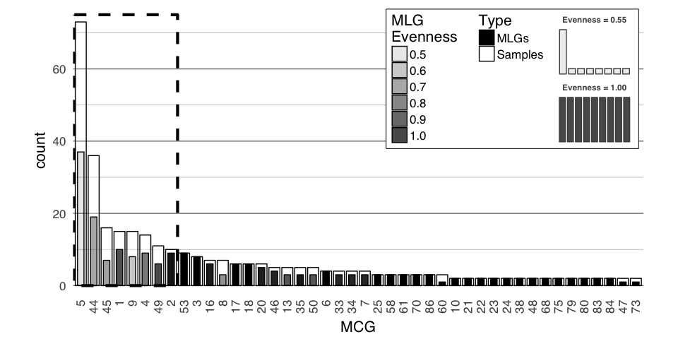

```r
even <- mcgs %>%
  filter(MCG %in% c(53, 9)) %>%
  mutate(MCG = ifelse(MCG == 53, "Evenness = 1.00", "Evenness = 0.55")) %>%
  unnest() %>%
  ggplot(aes(x = forcats::fct_inorder(MLG), y = Freq, alpha = Evenness)) +
  geom_col(color = "grey30", width = 0.75) +
  theme_void() +
  theme(strip.text = element_text(family = "Helvetica", color = "grey30", face = "bold")) +
  theme(aspect.ratio = 0.66) +
  theme(panel.spacing = unit(0, "line")) +
  theme(legend.position = "none") +
  # theme(plot.background = element_rect(fill = NA, colour = "black")) +
  facet_wrap(~MCG, ncol = 1, scale = "free")
# vp1 <- grid::viewport(width = 0.25, height = 0.4, x = 1, y = 0.975, just = c("right", "top"))
# mcg_graph <- mcg_graph + theme(legend.position = c(.763, .75))
# print(mcg_graph)
# print(even, vp = vp1)
mcg_graph_inset <- cowplot::ggdraw() +
  cowplot::draw_plot(mcg_graph, 0, 0, 1, 1) +
  cowplot::draw_plot(even, 0.75, 0.5675, 0.25, 0.4)
mcg_graph_inset
```

```r
if (!interactive()){
  cowplot::ggsave(mcg_graph_inset,
                  filename = file.path(PROJHOME, "results/figures/publication/mcg-barplot.pdf"),
                  width = 10,
                  height = 5,
                  units = "in")
  # pdf(file.path(PROJHOME, "results/figures/publication/Figure1Z.pdf"), width = 10, height = 5)
  # print(mcg_graph)
  # print(even, vp = vp1)
  # dev.off()
}
```

```
Ignoring unknown aesthetics: width
```

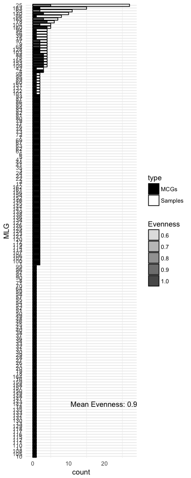

```r
mlgs %>%
  gather(type, count, MCGs, Samples, -Evenness) %>%
  arrange(desc(type), count) %>%
  mutate(MLG = forcats::fct_inorder(MLG, ordered = TRUE)) %>%
  ggplot(aes(x = MLG, y = count, group = type, fill = type)) +
  geom_col(aes(width = ifelse(type == "MCGs", 0.5, 0.85), alpha = Evenness), color = "black", position = "identity") +
  annotate(geom = "text", x = 20, y = 21, label = sprintf("Mean Evenness: %.3f", mean(mlgs$Evenness, na.rm = TRUE))) +
  # scale_fill_viridis(end = 0.75, discrete = TRUE, direction = -1) +
  scale_fill_manual(values = c("black", "white")) +
  scale_y_continuous(expand = c(0, 2)) +
  theme_minimal() +
  theme(panel.grid.major.x = element_blank()) +
  coord_flip()
```

```r
  # theme(axis.text.x = element_text(angle = 90, vjust = 0.5, hjust = 1)) +
  ggtitle("How Evenly are MCGs spread across Multilocus Genotypes (MLGs)?")
```

```
$title
[1] "How Evenly are MCGs spread across Multilocus Genotypes (MLGs)?"

$subtitle
NULL

attr(,"class")
[1] "labels"
```

# Making a Graph

I believe that making a graph to visualize this might help me understand what the h*ck is going on.

```r
make_mcgmlg_graph <- function(x){
  gdf <- mutate(x, MLG = paste0('MLG.', MLG))
  MLGS <- gdf %>%
    group_by(MLG) %>%
    summarize(size = sum(Freq)) %>%
    rename(vertex = MLG)
  MCGS <- gdf %>%
    group_by(MCG) %>%
    summarize(size = sum(Freq)) %>%
    rename(vertex = MCG)
  VAT <- bind_rows(MLGS, MCGS)
  g <- gdf %>%
    select(MLG, MCG, Freq) %>%
    rename(weight = Freq) %>%
    graph_from_data_frame(vertices = VAT)
  V(g)$type <- ifelse(grepl("MLG", V(g)$name), "Multilocus Genotype", "Mycelial Compatibility Group")
  g
}
add_communities <- function(g, clusters){
  comm <- communities(clusters)
  commlist <- setNames(rep(names(comm), lengths(comm)), unlist(comm, use.names = FALSE))
  V(g)$community <- commlist[V(g)$name]
  g
}
g <- make_mcgmlg_graph(mcgmlg)
g <- add_communities(g, cluster_walktrap(g))
osize <- V(g)$size
```

Because I have more control over the size and feel of the graph, I’m going to use ggraph. Of course, since this IS a complicated data set, It’s not going to be very pretty to look at, but I’m going to save it as supplementary materials because it’s valuable to at least look this ugliness in the face and say, “Yeah, I guess it’s not so simple after all.”

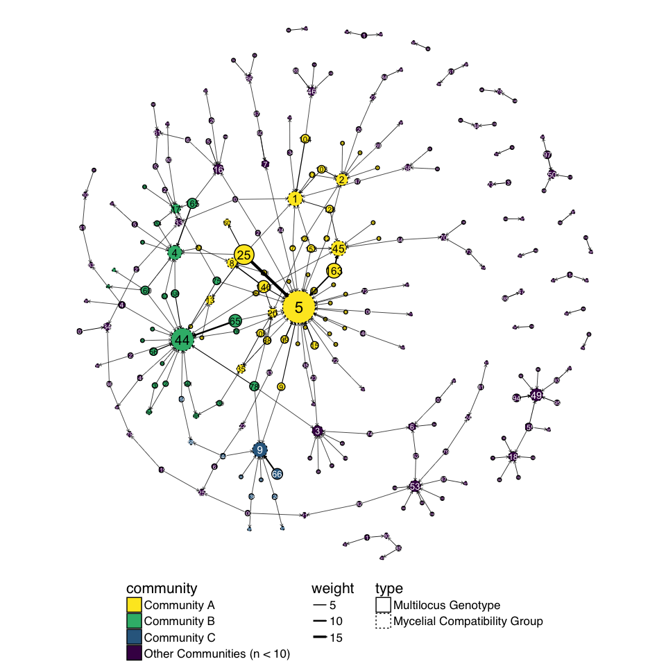

```r
V(g)$size <- sqrt(osize)/10
set.seed(2017-05-03)
# set.seed(2017-08-02)
lay2 <- create_layout(g, layout = "igraph",
                      algorithm = "fr",
                      weights = rep(1, length(E(g)$weight))
                      # weights = ifelse(E(g)$weight == 1, 1, 1 + E(g)$weight/100)
                      )
the_communities <- data_frame(vertex = lay2$name, community = lay2$community) %>%
  mutate(comm = case_when(
    .$community == 7 ~ "A",
    .$community == 5 ~ "B",
    .$community == 1 ~ "C",
    TRUE ~ as.character(.$community)
  )) %>%
  group_by(community) %>%
  mutate(comm = ifelse(n() > 10, paste("Community", comm), "Other Communities (n < 10)")) %>%
  mutate(comm = comm) # It just so happens that the communities are in order by size.
lay2$community <- the_communities$comm
mcg_mlg_graph <- ggraph(lay2) +
  geom_node_circle(aes(r = size, lty = type, fill = community)) +
  geom_edge_link(aes(start_cap = circle(node1.size, unit = "native"),
                     end_cap = circle(node2.size, unit = "native"),
                     width = weight),
                 arrow = arrow(length = unit(0.005, "native"))) +
  geom_node_text(aes(label = gsub("MLG.", "", name),
                     color = community,
                     size = size/10),
                 show.legend = FALSE) +
  coord_fixed() +
  scale_linetype_manual(values = c(1, 3)) +
  scale_edge_width(range = c(0.25, 1.5)) +
  scale_color_manual(values = c("black", "black", "white", "white")) +
  scale_fill_viridis(direction = -1, discrete = TRUE) +
  theme_graph(base_size = 16, base_family = "Helvetica") +
  theme(legend.position = "bottom", legend.direction = "vertical") +
  theme(legend.box.spacing = unit(-1, "lines")) +
  theme(plot.margin = unit(c(0, 0, 0, 0), "lines"))
  # ggtitle("Relation of Multilocus Genotypes and MCGs")

mcg_mlg_graph
```

```r
if (!interactive()){
  ggsave(plot = mcg_mlg_graph, filename = file.path(PROJHOME, "results/figures/publication/full-graph.pdf"),
       width = 88*3, height = 88*3.5, units = "mm")
  tmp <- new.env()
  assign("mcg_mlg_igraph", g, envir = tmp)
  assign("mcg_mlg_gg", mcg_mlg_graph, envir = tmp)
  V(tmp$mcg_mlg_igraph)$size <- osize
  save(list = ls(envir = tmp),
       envir = tmp,
       file = file.path(PROJHOME, "data", "mcg-mlg-graph.rda"))
}
cat("Community Structure:\n")
```

```
Community Structure:
```

```r
cluster_walktrap(g)
```

```
IGRAPH clustering walktrap, groups: 51, mod: 0.71
+ groups:
  $`1`
   [1] "MLG.124" "MLG.136" "MLG.144" "MLG.156" "MLG.55"  "MLG.58"  "MLG.66"  "66"      "67"      "68"
  [11] "9"

  $`2`
  [1] "MLG.31" "MLG.4"  "MLG.41" "10"     "39"     "83"

  $`3`
  [1] "MLG.113" "MLG.85"  "32"      "40"      "80"

  + ... omitted several groups/vertices
```

Because showing this big, hairy graph can overload a reader, I’m creating an inset graph for later use.

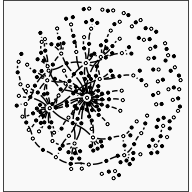

```r
mcg_mlg_graph2 <- ggraph(lay2) +
  geom_edge_arc(#aes(width = weight),
                start_cap = circle(1.1, "mm"),
                end_cap = circle(1.1, "mm"),
                curvature = 0.1
                ) + #arrow = arrow(length = unit(2, "mm"))) +
  geom_node_point(aes(fill = type), pch = 21, size = 0.75) +
  coord_fixed() +
  scale_edge_width(range = c(0.25, 1.5)) +
  scale_fill_manual(values = c("black", "white")) +
  theme_graph(base_size = 16, base_family = "Helvetica") +
  theme(legend.position = "none", legend.direction = "vertical") +
  # theme(legend.box.spacing = unit(-1, "lines")) +
  theme(plot.margin = unit(c(0, 0, 0, 0), "lines")) +
  theme(plot.background = element_rect(fill = "grey98", color = "black"))
mcg_mlg_graph2
```

Of interest is accounting for the communities that have a single MLG within the community. This gives us a lower bound at how many MLGs are reproductively isolated. We detect these by filtering for communities that only have one MLG. But, because we do have communities with one MLG that are peripheral to larger communities, we can also check the degree of the MCG and MLG nodes to ensure that they correspond one-to-one.

```r
singles <- the_communities %>%
  mutate(MLG = grepl("MLG", vertex)) %>%
  group_by(community) %>%
  summarize(n = sum(MLG)) %>%
  filter(n == 1) %>%
  inner_join(the_communities, by = "community") %>%
  mutate(type = case_when(grepl("MLG", vertex) ~ "MLG", TRUE ~ "MCG")) %>%
  group_by(community, type) %>%
  summarize(vertex = paste(as.character(vertex), collapse = ", ")) %>%
  spread(type, vertex) %>%
  mutate(MCG_degree = map_dbl(strsplit(MCG, ", "), . %>% degree(g, .) %>% sum())) %>%
  mutate(MLG_degree = degree(g, MLG)) %>%
  filter(MLG_degree - MCG_degree == 0)
# assessing that this truely contains the singletons
nrow(inner_join(singles, the_communities, by = c("MLG" = "vertex")))
```

```
Column `MLG`/`vertex` joining character vector and factor, coercing into character vector
```

```
[1] 15
```

```r
singles
```

| community | MCG | MLG | MCG_degree | MLG_degree |
| --- | --- | --- | --- | --- |
| 35 | 26, 82 | MLG.61 | 2 | 2 |
| 36 | 36, 37 | MLG.114 | 2 | 2 |
| 39 | 14, 29 | MLG.1 | 2 | 2 |
| 40 | 87 | MLG.135 | 1 | 1 |
| 41 | 85 | MLG.116 | 1 | 1 |
| 42 | 76 | MLG.50 | 1 | 1 |
| 43 | 63 | MLG.49 | 1 | 1 |
| 44 | 57 | MLG.143 | 1 | 1 |
| 45 | 74 | MLG.32 | 1 | 1 |
| 46 | 62 | MLG.34 | 1 | 1 |

[output cut: 5 more lines]

```r
knitr::kable(singles)
```

| community | MCG | MLG | MCG_degree | MLG_degree |
| --- | --- | --- | --- | --- |
| 35 | 26, 82 | MLG.61 | 2 | 2 |
| 36 | 36, 37 | MLG.114 | 2 | 2 |
| 39 | 14, 29 | MLG.1 | 2 | 2 |
| 40 | 87 | MLG.135 | 1 | 1 |
| 41 | 85 | MLG.116 | 1 | 1 |
| 42 | 76 | MLG.50 | 1 | 1 |
| 43 | 63 | MLG.49 | 1 | 1 |
| 44 | 57 | MLG.143 | 1 | 1 |
| 45 | 74 | MLG.32 | 1 | 1 |
| 46 | 62 | MLG.34 | 1 | 1 |
| 47 | 55 | MLG.142 | 1 | 1 |
| 48 | 47 | MLG.98 | 1 | 1 |
| 49 | 12 | MLG.14 | 1 | 1 |
| 50 | 54 | MLG.118 | 1 | 1 |
| 51 | 73 | MLG.137 | 1 | 1 |

This result indicates that there are 15 MLGs that are unable to pair with any other MLGs due to mycelial incompatibility. This represents 9.09% of the total MLGs.

```
          MLG.61 MLG.114 MLG.1 MLG.135 MLG.116 MLG.50 MLG.49 MLG.143 MLG.32 MLG.34 MLG.142 MLG.98 MLG.14
OR             0       0     1       0       0      0      0       0      0      0       0      0      1
WA             1       0     0       0       0      1      1       1      1      1       1      0      0
Australia      0       0     0       0       1      0      0       0      0      0       0      0      0
CA             1       0     1       0       0      0      0       0      0      0       0      0      0
France         0       2     0       0       0      0      0       0      0      0       0      0      0
Mexico         0       0     0       0       0      0      0       0      0      0       0      2      0
ND             0       0     0       1       0      0      0       0      0      0       0      0      0
          MLG.118 MLG.137
OR              0       0
WA              1       2
Australia       0       0
CA              0       0
France          0       0
Mexico          0       0
ND              0       0
```

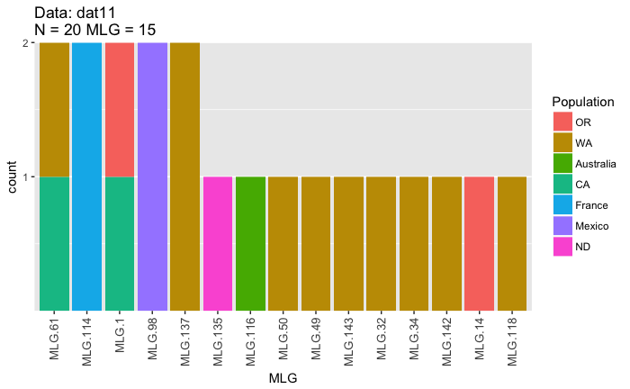

```r
mll(dat11) <- "original"
mlg.table(dat11, ~Region, color = TRUE, mlgsub = as.integer(gsub("MLG.", "", singles$MLG)))
```

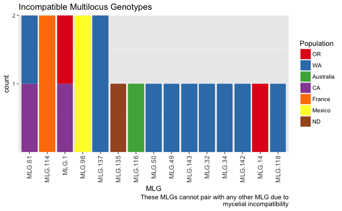

```r
p <- last_plot()
p +
  scale_fill_brewer(palette = "Set1") +
  ggtitle("Incompatible Multilocus Genotypes") +
  labs(list(caption = "These MLGs cannot pair with any other MLG due to\nmycelial incompatibility"))
```

The opposite question is, how connected is this huge hairy mess? The community analysis gave us an idea of where different centers lie, but it doesn’t really do much for us in actually giving us an idea of what the possabilities for connection are. One way we can look at this is by using the `ego()` function to assess the neighborhood of vertices for a given node order, which is to say the number of edges away from the node you must travel to visit all your neighbors. Order 0 would give us the node itself, and order 1 would give us the degree plus one. If we set this degree to a large number, we will find all the possible connections.

Here I’m getting a simple measure by counting all the vertices, I’m subtracting two here because I want to remove the genotype and the MCG associated.

```r
# getting the sizes for all genotypes.
sizes <- ego_size(g, 200, nodes = which(grepl("Genotype", V(g)$type)), mode = "all") - 2
table(sizes)
```

```
sizes
  0   1   3  13 186
 12   7   5  11 130
```

To focus on strictly the MLGs, we can see a more clear picture. Here, we are taking the results of `ego()` and counting how many MLGs are in the vertex list. From there, we can tabulate the results and divide the number of entries by the category, giving us the number of communities in each category.

```r
ncommunities <- ego(g, 200, nodes = which(grepl("Genotype", V(g)$type)), mode = "all") %>%
  map_int(. %>% names %>% grepl("MLG", .) %>% sum) %>%
  table() %>%
  {./as.integer(names(.))}
ncommunities
```

```
.
  1   2   3  11 130
 15   3   1   1   1
```

```r
map_dbl(as.integer(names(ncommunities)), choose, 2)
```

```
[1]    0    1    3   55 8385
```

From here, we can see that we have 15 MLGs that only interact with themselves, 3 pairs of MLGs, 1 triplet, 1 hendeclet, and 1 community with 130 members, of which there are 8385 possible combinations.

Of course, the 8385 possible combinations doesn’t give us an idea of what the number of immediately possible combinations exist. We can examine that by setting the mode to 2.

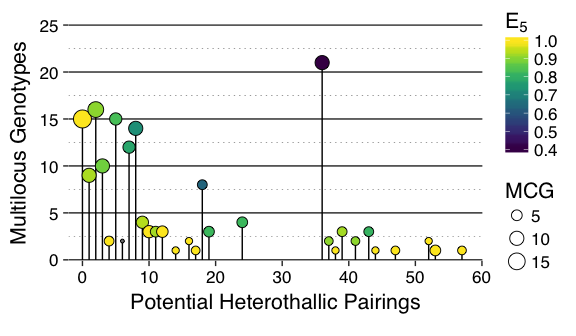

The maximum here is 57, which represents MLG.75.

## Interactive Visualizations

The *visNetwork* package wraps a java library that has very good network visualization routines. I can conver this graph to that.

```r
make_rgb <- function(x, alpha = 1){
  out <- col2rgb(x, alpha = TRUE)
  out[4, ] <- floor(out[4, ]*alpha)
  out      <- apply(out, 2, paste, collapse = ", ")
  paste0("rgba(", out, ")")
}
community_colors <- viridis::viridis(4, direction = -1)[as.integer(factor(the_communities$comm))]
vg <- g %>%
  set_vertex_attr("size", value = osize * 10) %>%
  set_vertex_attr("value", value = osize) %>%
  set_vertex_attr("label", value = NULL) %>%
  set_vertex_attr("color", value = community_colors) %>%
  set_vertex_attr("shape", value = ifelse(V(.)$type == "Multilocus Genotype", "triangle", "dot")) %>%
  set_edge_attr("width", value = E(.)$weight) %>%
  toVisNetworkData()
vg$nodes <- vg$nodes %>%
  dplyr::group_by(id) %>%
  dplyr::mutate(color = list(list(background = make_rgb(color, 0.8),
                      border = make_rgb(rep("black", n()), 0.8),
                      highlight = list(background = make_rgb(color),
                                       border = make_rgb(rep("black", n()))
                                       )
                      ))) %>%
  dplyr::mutate(title = paste0("<p>",
                               "<i>", type, " ", gsub("MLG.", "", id), "</i><br>",
                               "<b>Community: ", community, "</b><br>",
                               "<b>N: ", size/10, "</b><br>",
                               "</p>")
                )
vg$edges <- vg$edges %>%
  dplyr::mutate(title = paste0("<p>",
                        "<b>Mycelial Compatibility Group: ", from, "</b><br>",
                        "<b>Multilocus Genotype: ", gsub("MLG.", "", to), "</b><br>",
                        "<b>N: ", weight, "</b>",
                        "</p>")
         )
vgn <- visNetwork(nodes = vg$nodes, edges = vg$edges,# height = "500px",
                  main = "Relation of Multilocus Genotypes and MCGs")
set.seed(2017-05-03)

vgn %>%
  # visIgraphLayout("layout_nicely") %>% # activate this for a poseable network
  visNodes(label = NULL, shadow = TRUE) %>%
  visOptions(highlightNearest = list(enabled = TRUE, hover = TRUE),
             nodesIdSelection = TRUE)
```

## Subgraph

```r
top5 <- filter(mcgmlg, as.character(MCG) %in% (mcgs %>% arrange(desc(Samples)) %>% slice(1:8) %>% pull(MCG)))
top5g <- make_mcgmlg_graph(top5)
tosize <- V(top5g)$size
V(top5g)$size <- sqrt(tosize)/10
# set.seed(2017-05-08)
set.seed(2017-08-1)
top5lay <- create_layout(top5g, layout = "igraph", algorithm = "fr", weights = rep(1, length(E(top5g))))
top5lay$community <- inner_join(data_frame(vertex = top5lay$name), the_communities)$comm
```

```
Column `vertex` joining factors with different levels, coercing to character vector
```

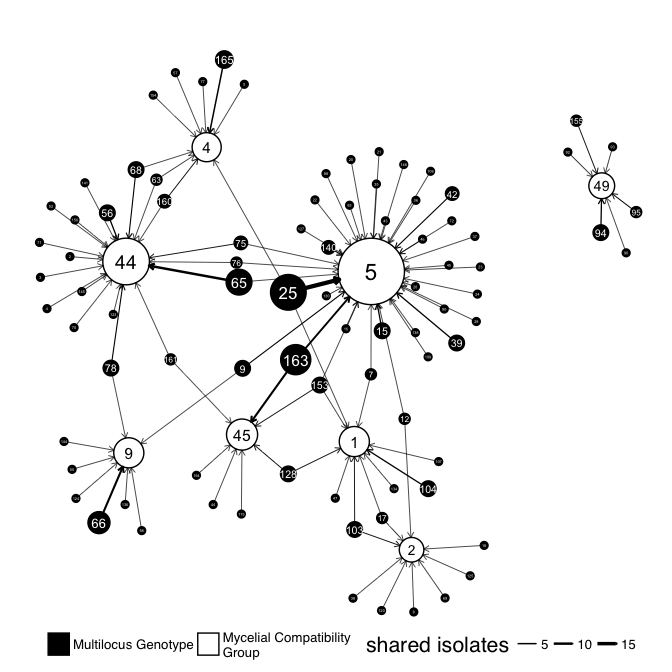

```r
levels(top5lay$type) <- c("Multilocus Genotype", "Mycelial Compatibility\nGroup")
t5g <- ggraph(top5lay) +
  geom_node_circle(aes(r = size, fill = type)) +
  geom_edge_link(aes(start_cap = circle(node1.size, unit = "native"),
                     end_cap = circle(node2.size, unit = "native"),
                     width = weight),
                 arrow = arrow(length = unit(0.01, "native"))) +
  geom_node_text(aes(label = gsub("MLG.", "", name),
                     color = type,
                     size = size/10),
                 show.legend = FALSE) +
  coord_fixed() +
  scale_edge_width(range = c(0.25, 1.5)) +
  scale_fill_manual(values = c("black", "white")) +
  scale_color_manual(values = c("white", "black")) +
  theme_graph(base_size = 16, base_family = "Helvetica") +
  # theme(legend.position = c(0.85, 0.35), legend.direction = "vertical") +
  theme(legend.position = c(0.5, 0), legend.direction = "horizontal", legend.box = "horizontal") +
  theme(legend.box.spacing = unit(-1, "lines")) +
  theme(legend.spacing.x = unit(0, "lines")) +
  # theme(legend.box.background = element_rect(color = "black")) +
  theme(legend.text = element_text(size = 10)) +
  theme(plot.margin = unit(c(0, 0, 0, 0), "lines"))
t5g$labels$edge_width <- "shared isolates"
t5g$labels$fill <- ""
t5g
```

```r
if (!interactive())
  ggsave(t5g, file = file.path("results", "figures", "publication", "mcg-mlg-subgraph.pdf"), width = 88, height = 88, scale = 3, units = "mm")
```

Vey nice!

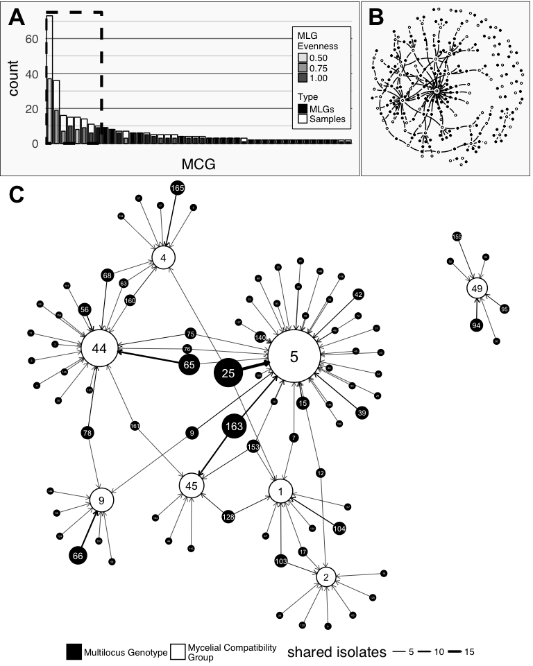

```r
greyground <- theme(plot.background = element_rect(color = "black", fill = "grey98"))
mcg_theme <- theme(legend.text = element_text(size = 10)) +
  theme(legend.title = element_text(size = 10)) +
  theme(axis.text.x = element_blank()) +
  # theme(legend.background = element_blank()) +
  theme(legend.box.background = element_rect(fill = "grey98")) +
  theme(legend.key.size = unit(0.75, "line")) +
  theme(legend.box.just = "left") +
  theme(legend.position = c(0.9, 0.5)) +
  theme(legend.box = "vertical") +
  theme(legend.box.margin = unit(c(0, 0, 0, 0), "lines")) +
  theme(legend.spacing = unit(0, "lines")) +
  theme(aspect.ratio = 0.45) +
  greyground
mcg_subgraph_with_context <- cowplot::ggdraw(xlim = c(0, 2), ylim = c(0, 2.25)) +
  cowplot::draw_plot(t5g, 0, -0.125, 2, 2) +
  cowplot::draw_plot(mcg_graph + scale_alpha(breaks = c(0.5, 0.75, 1)) + mcg_theme, 0, 1.45, 1.35, 1) +
  cowplot::draw_plot(mcg_mlg_graph2 + greyground, x = 1.355, y = 1.633, width = 0.6345, height = 0.6345) +
  cowplot::draw_plot_label(c("A", "B", "C"), x = c(0, 1.35, 0), y = c(2.25, 2.25, 1.65), size = 25)
mcg_subgraph_with_context
```

```r
if (!interactive()){
  cowplot::ggsave(plot = mcg_subgraph_with_context,
                  filename = file.path(PROJHOME, "results", "figures", "publication", "mcg-subgraph-with-context.pdf"),
                  width = 8,
                  height = 10)
}
```

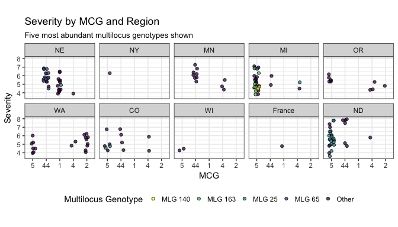

```r
count_group <- . %>%
  mutate(nobs = n()) %>%  # count the number of samples/MCG
  ungroup() %>%
  arrange(desc(nobs)) # arrange by number of samples and reorder factors
Severity <- filter(strat, MCG %in% mcgs$MCG[1:5]) %>%
  group_by(MCG) %>%
  count_group %>%
  mutate(MCG = forcats::fct_inorder(factor(MCG), ordered = TRUE)) %>%
  mutate(MLG = ifelse(MLG %in% mlgs$MLG[1:5], paste("MLG", MLG), "Other"))

severity_plot <- ggplot(Severity, aes(x = MCG, y = Severity)) +
  geom_point(aes(fill = MLG),
             position = position_jitter(width = 0.2),
             alpha = 0.75,
             pch = 21) +
  scale_fill_viridis(discrete = TRUE, direction = -1) +
  theme_bw() +
  theme(legend.position = "bottom") +
  theme(aspect.ratio = 0.6) +
  facet_wrap(~Region, nrow = 2) +
  ylim(c(3.5, 8)) +
  labs(list(
    title = "Severity by MCG and Region",
    fill = "Multilocus Genotype",
    subtitle = "Five most abundant multilocus genotypes shown"
  ))
severity_plot
```

```r
if (!interactive())
  ggsave(severity_plot, filename = "results/figures/publication/FigureS3.pdf", width = 183, unit = "mm")
```

# MCG accumulation permutations

On 2017-07-27, Sydney came up with the idea to assess MCG accumulation with increasing genetic distance similar to the genotype accumulation curve. First, let’s see what the curve would look like if we had one MLG/MCG.

First, we need to set up everything to calculate this quantity

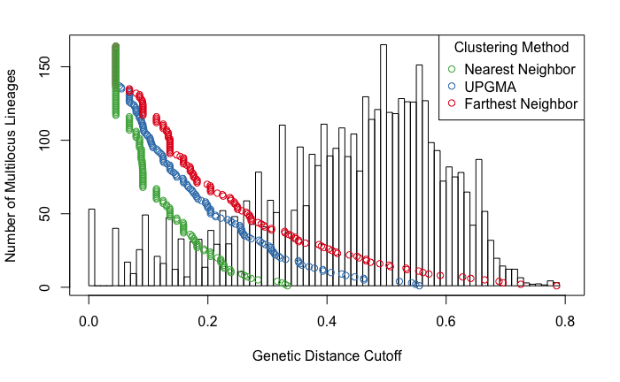

```r
bd         <- bruvo.dist(dat11, replen = other(dat11)$REPLEN)
thresholds <- filter_stats(dat11, distance = bd, plot = TRUE)
```

```r
thresh     <- c(0, unique(thresholds$farthest$THRESHOLDS) + .Machine$double.eps)
collapsed  <- map(thresh, . %>% mlg.filter(dat11, threshold = ., distance = bd))
# This function will count the number of original MLGs within each collapsed MLG
# Note that "original" here can be any MLG source.
compare_mlg <- function(collapsed, thresh, original){
  as_tibble(list(MLG = collapsed, y = original, threshold = thresh)) %>%
    group_by(MLG, threshold) %>%
    summarize(N = n_distinct(y)) %>%
    ungroup() %>%
    mutate(NMLG = n())
}
# A custom function for stat summary that returns a single point when there is
# only a single observation
my_meanse <- function (x, mult = 1) {
  x <- stats::na.omit(x)
  se <- mult * sqrt(stats::var(x)/length(x))
  mean <- mean(x)
  if (length(x) == 1) return(data.frame(y = mean, ymin = mean, ymax = mean))
  data.frame(y = mean, ymin = mean - se, ymax = mean + se)
}
```

Now, as a demontration, we can see what the curve would look like if all MCGs were randmly distributed (e.g. not clumpy) among the MLGs

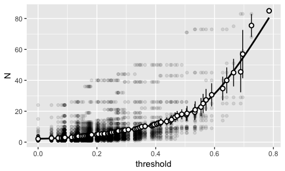

```r
map2_df(collapsed, thresh, compare_mlg, original = sample(87, 366, replace = TRUE)) %>%
  ggplot(aes(x = threshold, y = N)) +
  geom_point(alpha = 0.1) +
  stat_smooth(se = FALSE, color = "black") +
  stat_summary(pch = 21, fun.data = my_meanse, fill = "white")
```

Now we can see what it looks like when there is a 1:1 relationship of MCGs to MLGs:

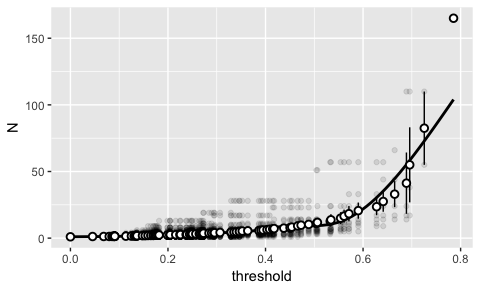

```r
map2_df(collapsed, thresh, compare_mlg, original = mll(dat11, "original")) %>%
  ggplot(aes(x = threshold, y = N)) +
  geom_point(alpha = 0.1) +
  stat_smooth(se = FALSE, color = "black") +
  stat_summary(pch = 21, fun.data = my_meanse, fill = "white")
```

Yet another comparison would be if each sample were a unique MCG:

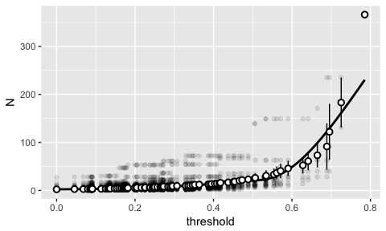

```r
map2_df(collapsed, thresh, compare_mlg, original = seq(366)) %>%
  ggplot(aes(x = threshold, y = N)) +
  geom_point(alpha = 0.1) +
  stat_smooth(se = FALSE, color = "black") +
  stat_summary(pch = 21, fun.data = my_meanse, fill = "white")
```

And it’s worth examining what happens if there are only 10 MCGs:

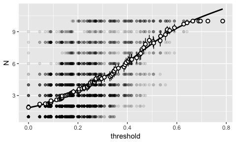

```r
map2_df(collapsed, thresh, compare_mlg, original = sample(10, 366, replace = TRUE)) %>%
  ggplot(aes(x = threshold, y = N)) +
  geom_point(alpha = 0.1) +
  stat_smooth(se = FALSE, color = "black") +
  stat_summary(pch = 21, fun.data = my_meanse, fill = "white")
```

And, of course, we should see what our observed data looks like:

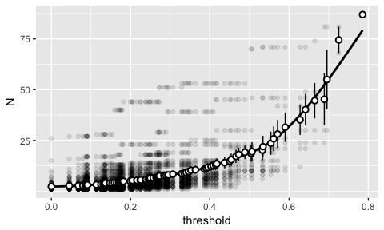

```r
observed <- map2_df(collapsed, thresh, compare_mlg, original = mll(dat11, "custom")) %>%
  mutate(sample_number = "observed") %>%
  mutate(source = "observed")
# Revisiting random dist
map2_df(collapsed, thresh, compare_mlg, original = sample(87, 366, replace = TRUE)) %>%
  ggplot(aes(x = threshold, y = N)) +
  geom_point(alpha = 0.1) +
  stat_smooth(se = FALSE, color = "black") +
  scale_y_continuous(breaks = c(25, 50, 75)) +
  stat_summary(pch = 21, fun.data = my_meanse, fill = "white")
```

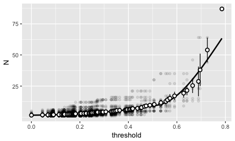

```r
observed %>%
  ggplot(aes(x = threshold, y = N)) +
  geom_point(alpha = 0.1) +
  stat_smooth(se = FALSE, color = "black") +
  scale_y_continuous(breaks = c(25, 50, 75)) +
  stat_summary(pch = 21, fun.data = my_meanse, fill = "white")
```

```r
set.seed(5000)
random   <- map_df(1:20, function(x) map2_df(collapsed, thresh, compare_mlg, original = sample(mll(dat11, "custom"))), .id = "sample_number") %>%
  mutate(sample_number = sprintf("%3d", as.integer(sample_number))) %>%
  mutate(source = "random")
```

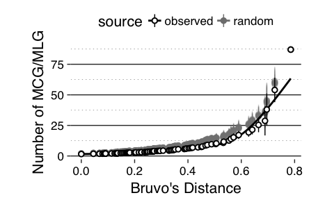

```r
ggplot(random, aes(x = threshold, y = N, group = sample_number, color = source, fill = source)) +
  # geom_point(alpha = 0.01, color = "grey50") +
  stat_summary(alpha = 0.125, fun.data = my_meanse) +
  # geom_point(alpha = 0.5, pch = 21, data = observed, fill = "white") +
  stat_smooth(se = FALSE, data = observed) +
  stat_summary(pch = 21, fun.data = my_meanse, data = observed) +
  scale_color_manual(values = c("black", "grey50")) +
  scale_fill_manual(values = c("white", "grey50")) +
  theme_bw(base_size = 16, base_family = "Helvetica") +
  theme(aspect.ratio = 1/2) +
  theme(axis.text = element_text(color = "black")) +
  theme(panel.grid.major = element_line(colour = "grey20")) +
  theme(panel.grid.minor = element_line(colour = "grey50", linetype = 3)) +
  theme(panel.grid.major.x = element_blank()) +
  theme(panel.grid.minor.x = element_blank()) +
  theme(panel.border = element_blank()) +
  theme(legend.position = "top") +
  ylab("Number of MCG/MLG") +
  xlab("Bruvo's Distance")
```

# Assessing MCG/MLG community structure/cohesiveness

The communities defined above are defined by the connections between different MCGs. There is still the question of how cohesive these communities are. I believe one way to investigate this is to add the communities assignments back to the data and assess how well they split up on a dendrogram created with genetic distance.

```r
strat_mcg <- left_join(strat, the_communities, by = c("MCG" = "vertex"))
```

```
Column `MCG`/`vertex` joining factors with different levels, coercing to character vector
```

```r
datdist   <- bruvo.dist(dat11, replen = other(dat)$REPLEN)
datree    <- phangorn::upgma(datdist)
```

Now we can visualize that trees.

```r
ape::plot.phylo(ape::ladderize(datree), type = "fan", no.margin = FALSE, tip.col = viridis(4, direction = -1)[as.integer(factor(strat_mcg$comm))])
legend(-0.015, 0.11, legend = levels(factor(strat_mcg$comm)), fill = viridis(4, direction = -1), bty = "n")
```

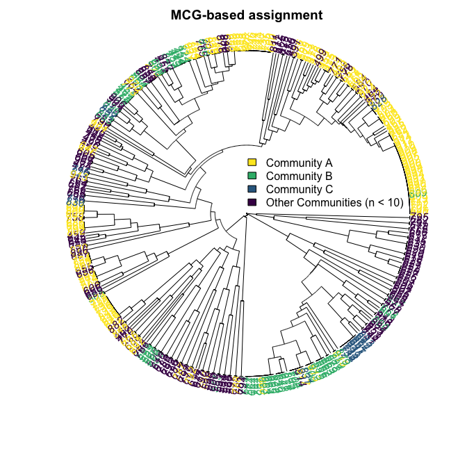

```r
title("MCG-based assignment")
```

```r
ape::plot.phylo(ape::ladderize(datree), type = "fan", no.margin = FALSE, tip.col = plasma(366)[rank(strat$Severity, ties.method = "first")])
legend(-0.015, 0.125, legend = quantile(strat$Severity), fill = plasma(5), bty = "n")
```

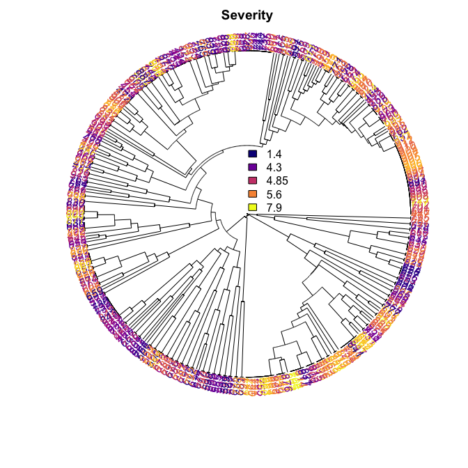

```r
title("Severity")
```

From what I can see, it appears that there’s not much of a tight correlation of genetic structure and MCG. There is the clear cluster of MLG 66 in Community C, but there are other isolates in distant parts of the tree. I’m wondering what happens if we average the distances between groups.

```r
datmat <- as.matrix(datdist)
distmcg <- strat_mcg %>%
  group_by(comm) %>%
  summarize(dist = list(datmat[Isolate, Isolate]), N = n())
isolist <- strat_mcg %>%
  group_by(comm) %>%
  filter(!duplicated(MLG)) %>%
  summarize(Isolates = list(Isolate)) %>%
  inner_join(expand(., comm, comm)) %>%
  rowwise() %>%
  mutate(COMMS = paste(sort(c(comm, comm1)), collapse = " ")) %>%
  ungroup() %>%
  filter(!duplicated(COMMS))
isolist <- isolist %>%
  filter(comm == comm1) %>%
  select(-comm, -COMMS) %>%
  rename(Isolates2 = Isolates) %>%
  inner_join(isolist)
distmcg <- isolist  %>%
  group_by(comm, comm1, COMMS) %>%
  summarize(dist = list(datmat[Isolates[[1]], Isolates2[[1]]]),
            N = length(Isolates[[1]])) %>%
  rowwise() %>%
  mutate(dist = case_when(isSymmetric(dist) ~ list(dist[lower.tri(dist)]),
                          TRUE ~ list(as.numeric(dist))))
distmcg %>%
  rowwise() %>%
  mutate(mean   = mean(dist),#mean(ifelse(dist == 0, NA, dist), na.rm = TRUE),
         median = median(dist)) %>%#median(ifelse(dist == 0, NA, dist), na.rm = TRUE)) %>%
  ungroup() %>%
  select(COMMS, mean, median, N) %>%
  rename(Comparison = COMMS) %>%
  knitr::kable()
```

| Comparison | mean | median | N |
| --- | --- | --- | --- |
| Community A Community A | 0.3938339 | 0.4204102 | 59 |
| Community A Community B | 0.4570305 | 0.4770508 | 59 |
| Community A Community C | 0.4640803 | 0.4857511 | 59 |
| Community A Other Communities (n < 10) | 0.4359960 | 0.4487083 | 59 |
| Community B Community B | 0.3998535 | 0.4279119 | 29 |
| Community B Community C | 0.4211572 | 0.4655540 | 29 |
| Community B Other Communities (n < 10) | 0.4662095 | 0.4872159 | 29 |
| Community C Community C | 0.4430856 | 0.5492276 | 9 |
| Community C Other Communities (n < 10) | 0.4870535 | 0.5195091 | 9 |
| Other Communities (n < 10) Other Communities (n < 10) | 0.4536293 | 0.4687472 | 103 |

```r
distplot <- distmcg %>%
  mutate(mean = mean(dist)) %>%
  mutate(COMMS = ifelse(comm == comm1, paste0(comm, "\n"), paste0(comm, "/\n", comm1))) %>%
  mutate(comm = gsub(" \\(", "\n(", comm)) %>%
  mutate(comm1 = gsub(" \\(", "\n(", comm1)) %>%
  mutate(comparison = ifelse(comm == comm1, "Within", "Among")) %>%
  ungroup() %>%
  unnest()
distplot %>%
  group_by(comparison) %>%
  summarize(mean = mean(dist), median = median(dist))
```

| comparison | mean | median |
| --- | --- | --- |
| Among | 0.4507717 | 0.4708141 |
| Within | 0.4368156 | 0.4545455 |

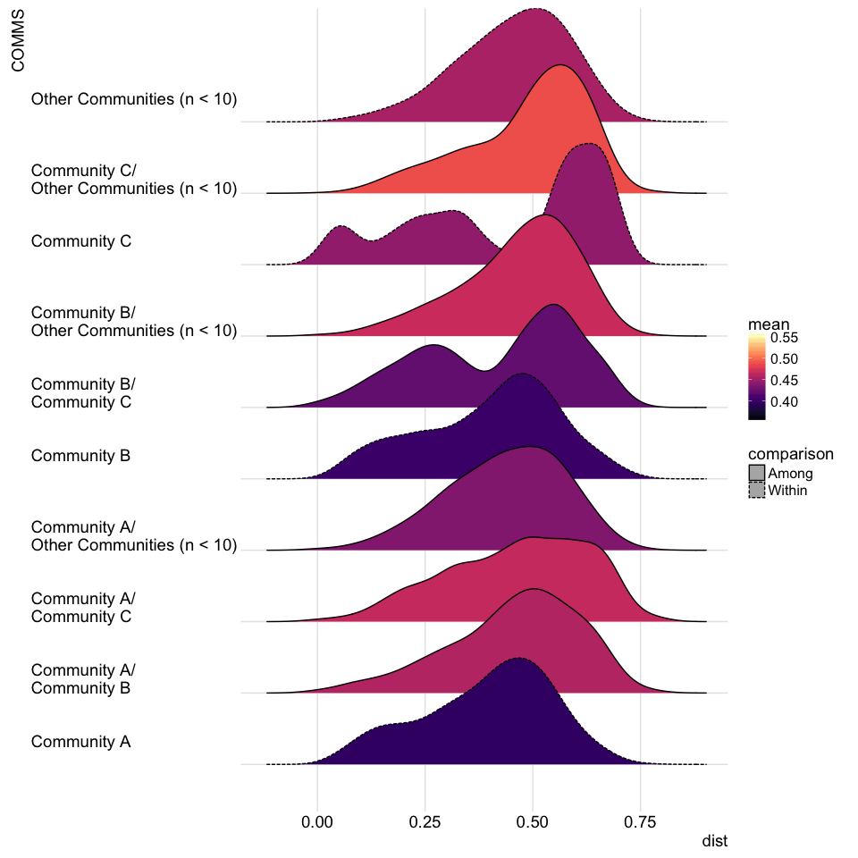

```r
if (require("ggjoy")){
  ggplot(distplot, aes(x = dist, y = COMMS, group = COMMS, height = ..density..)) +
    geom_joy(aes(lty = comparison, fill = mean)) +
    theme_joy() +
    theme(axis.text.y = element_text(hjust = 0)) +
    viridis::scale_fill_viridis(option = "A", limits = quantile(distplot$dist, c(0.25, 0.75)))
}
```

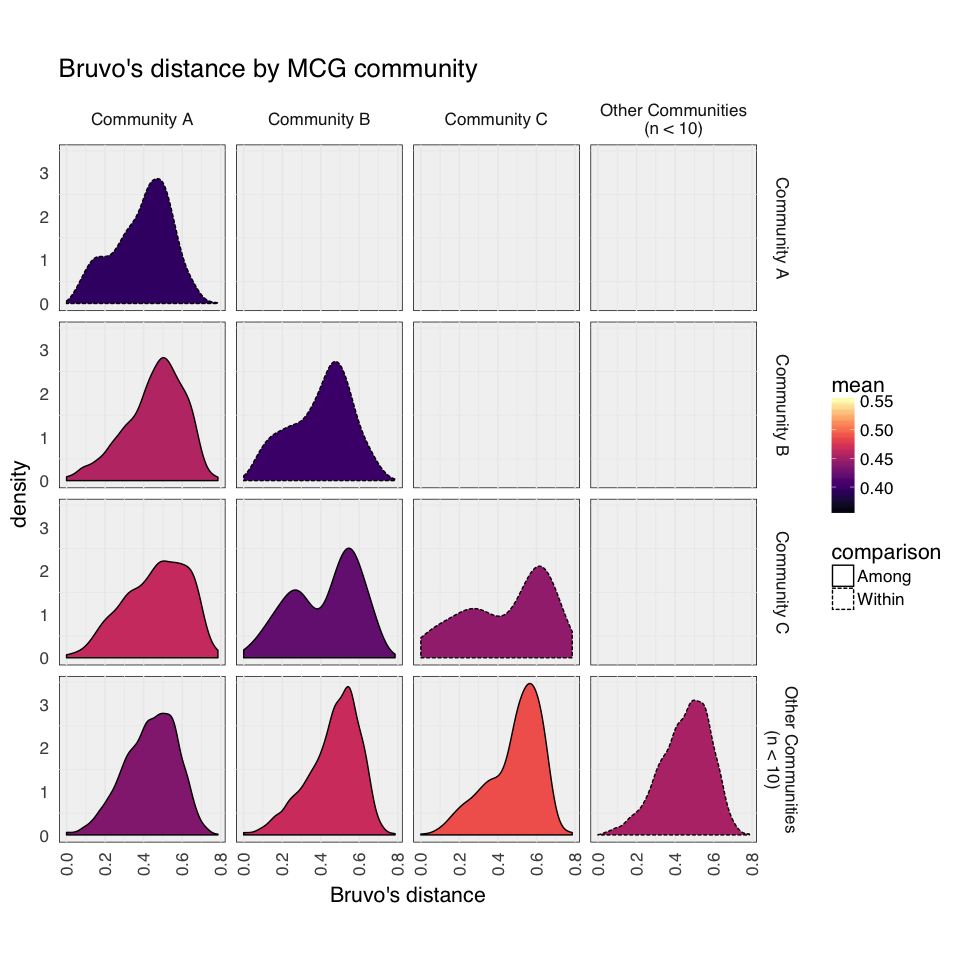

```r
ggplot(distplot, aes(x = dist, group = COMMS)) +
  geom_density(aes(fill = mean, lty = comparison)) +
  ggtitle("Bruvo's distance by MCG community") +
  xlab("Bruvo's distance") +
  facet_grid(comm1~comm) +
  theme_minimal(base_size = 16, base_family = "Helvetica") +
  theme(aspect.ratio = 1) +
  theme(panel.grid.major.y = element_blank()) +
  theme(panel.background = element_rect(fill = "grey95")) +
  theme(axis.text.x = element_text(angle = 90, vjust = 0.5, hjust = 1)) +
  viridis::scale_fill_viridis(option = "A", limits = quantile(distplot$dist, c(0.25, 0.75)))
```

```r
commamova <- dat11 %>%
  addStrata(data.frame(Community = strat_mcg$comm)) %>%
  clonecorrect(~Community) %>%
  poppr.amova(~Community, dist = as.dist(datmat[indNames(.), indNames(.)]),
              method = "pegas", nperm = 1000)
```

```
 No missing values detected.

Zero distance(s)
```

```r
commamova
```

```
    Analysis of Molecular Variance

Call: pegas::amova(formula = hier, data = hierdf, nperm = nperm, is.squared = FALSE)

                SSD       MSD  df
Community  2.408421 0.8028068   3
Error     41.926571 0.2139111 196
Total     44.334991 0.2227889 199

Variance components:
           sigma2 P.value
Community 0.01414       0
Error     0.21391

Variance coefficients:
       a
41.64667
```

This is quite distant. For reference, a distance of 0.32 is on average 7 steps.

```
 setting  value
 version  R version 3.4.1 (2017-06-30)
 system   x86_64, darwin15.6.0
 ui       RStudio (1.1.342)
 language (EN)
 collate  en_US.UTF-8
 tz       America/Chicago
 date     2017-08-22
```

```
Packages ------------------------------------------------------------------------------------------
```

```
 package      * version    date       source
 ade4         * 1.7-6      2017-03-23 CRAN (R 3.4.0)
 adegenet     * 2.1.0      2017-07-17 local
 ape            4.1        2017-02-14 CRAN (R 3.4.0)
 assertr        2.0.2.2    2017-06-06 CRAN (R 3.4.0)
 assertthat     0.2.0      2017-04-11 CRAN (R 3.4.0)
 backports      1.1.0      2017-05-22 CRAN (R 3.4.0)
 base         * 3.4.1      2017-07-07 local
 base64enc      0.1-3      2015-07-28 CRAN (R 3.4.0)
 bindr          0.1        2016-11-13 CRAN (R 3.4.0)
 bindrcpp     * 0.2        2017-06-17 CRAN (R 3.4.0)
 boot           1.3-20     2017-07-30 CRAN (R 3.4.1)
 broom          0.4.2      2017-02-13 CRAN (R 3.4.0)
 cellranger     1.1.0      2016-07-27 CRAN (R 3.4.0)
 cluster        2.0.6      2017-03-16 CRAN (R 3.4.0)
 coda           0.19-1     2016-12-08 CRAN (R 3.4.0)
 colorspace     1.3-2      2016-12-14 CRAN (R 3.4.0)
 compiler       3.4.1      2017-07-07 local
 cowplot        0.8.0      2017-07-30 CRAN (R 3.4.1)
 datasets     * 3.4.1      2017-07-07 local
 DBI            0.7        2017-06-18 CRAN (R 3.4.0)
 deldir         0.1-14     2017-04-22 CRAN (R 3.4.0)
 devtools       1.13.3     2017-08-02 CRAN (R 3.4.1)
 digest         0.6.12     2017-01-27 CRAN (R 3.4.0)
 dplyr        * 0.7.2      2017-07-20 CRAN (R 3.4.1)
 evaluate       0.10.1     2017-06-24 CRAN (R 3.4.1)
 expm           0.999-2    2017-03-29 CRAN (R 3.4.0)
 ezknitr        0.6        2016-09-16 CRAN (R 3.4.0)
 fastmatch      1.1-0      2017-01-28 CRAN (R 3.4.0)
 forcats        0.2.0      2017-01-23 CRAN (R 3.4.0)
 foreign        0.8-69     2017-06-21 CRAN (R 3.4.0)
 gdata          2.18.0     2017-06-06 CRAN (R 3.4.0)
 ggforce        0.1.1      2016-11-28 CRAN (R 3.4.0)
 ggjoy        * 0.3.0      2017-07-30 CRAN (R 3.4.1)
 ggplot2      * 2.2.1      2016-12-30 CRAN (R 3.4.0)
 ggraph       * 1.0.0      2017-02-24 CRAN (R 3.4.0)
 ggrepel        0.6.12     2017-08-02 Github (slowkow/ggrepel@fd15d0a)
 glue           1.1.1      2017-06-21 CRAN (R 3.4.0)
 gmodels        2.16.2     2015-07-22 CRAN (R 3.4.0)
 graphics     * 3.4.1      2017-07-07 local
```

[output cut: 62 more lines]

```
 tidyr        * 0.6.3      2017-05-15 CRAN (R 3.4.0)
 tidyverse    * 1.1.1      2017-01-27 CRAN (R 3.4.0)
 tools          3.4.1      2017-07-07 local
 tweenr         0.1.5      2016-10-10 CRAN (R 3.4.0)
 udunits2       0.13       2016-11-17 CRAN (R 3.4.0)
 units          0.4-5      2017-06-15 CRAN (R 3.4.0)
 utils        * 3.4.1      2017-07-07 local
 vegan          2.4-3      2017-04-07 CRAN (R 3.4.0)
 viridis      * 0.4.0      2017-03-27 CRAN (R 3.4.0)
 viridisLite  * 0.2.0      2017-03-24 CRAN (R 3.4.0)
 visNetwork   * 2.0.1      2017-07-30 cran (@2.0.1)
 withr          2.0.0      2017-07-28 CRAN (R 3.4.1)
 xml2           1.1.1      2017-01-24 CRAN (R 3.4.0)
 xtable         1.8-2      2016-02-05 CRAN (R 3.4.0)
 yaml           2.1.14     2016-11-12 CRAN (R 3.4.0)
```